# Individual Transmission Hazard Model

Sophia Ng, Josh Petrie, Richard R. Evans

October, 02, 2017

```r
suppressPackageStartupMessages(library(tidyverse))
```

Created by Sophia Ng on Aug 31, 2015. Modified by Josh Petrie on Nov 2, 2015. This script formats the data to be used in the likelihood function of the individual-based transmission hazard model for analysis of influenza infection risks from the household and from the community in a household COHORT study.

(can be adapted to any household based cohort study)

# Likelihood

The contribution to the likelihood for those NOT infected during follow up, and prior to the date of illness onset for those who were infected is:

$$e^{-\lambda_{pre}}$$

```
>R: exp(-1 * pre.haz)
```

pre.haz $(\lambda_{pre})$ is the sum of the hazards of infection from the community (pre.c.haz $(\lambda_{preC})$) and from the household (pre.hh.haz $(\lambda_{preHH})$) prior to infection:

$$\lambda_{pre} = \lambda_{preC} + \lambda_{preHH}$$

The additional contribution to the likelihood on the date of illness onset for those infected during follow up is:

$$1-e^{-\lambda_{on}}$$

```
>R: 1 - exp(-1 * on.haz)
```

The data are formatted into 4 lists (preinf.hh.exp, preinf.c.exp, ondate.hh.exp, ondate.c.exp) with 1 element (dataframe) per individual, j. The first two, preinf.hh.exp and preinf.c.exp, will be applied to exp(-1 * pre.haz), the likelihood for those not infected during follow up, and prior to the date of illness onset for those who were infected $(e^{-\lambda_{pre}})$.

- preinf.hh.exp
  - contains data for each day of household exposure, d(i, j), from each infected household contact, i, prior to j’s illness onset date or follow up end.
- preinf.c.exp
  - contains data for each day of community exposure, d(j), prior to j’s illness onset date or follow up end.

The final 2, ondate.hh.exp and ondate.c.exp, will be applied to 1 - exp(-1 * on.haz), the likelihood on the date of illness onset for those infected during follow up

- ondate.hh.exp
  - contains data for household exposure, d(i, j), from each infected household contact, i, on j’s illness onset date.
- ondate.c.exp
  - contains data for community exposure, d(j), on j’s illness onset date.

Each dataframe within the 4 lists also contains co-variate data, eg. Age, etc

# Protocol

## Load Data and Set-Up

Read in clean dataset: one row containing required info of each individual in the cohort including household ID, individual ID, illness onset date, end of follow up date, and all covariates to be included in regression

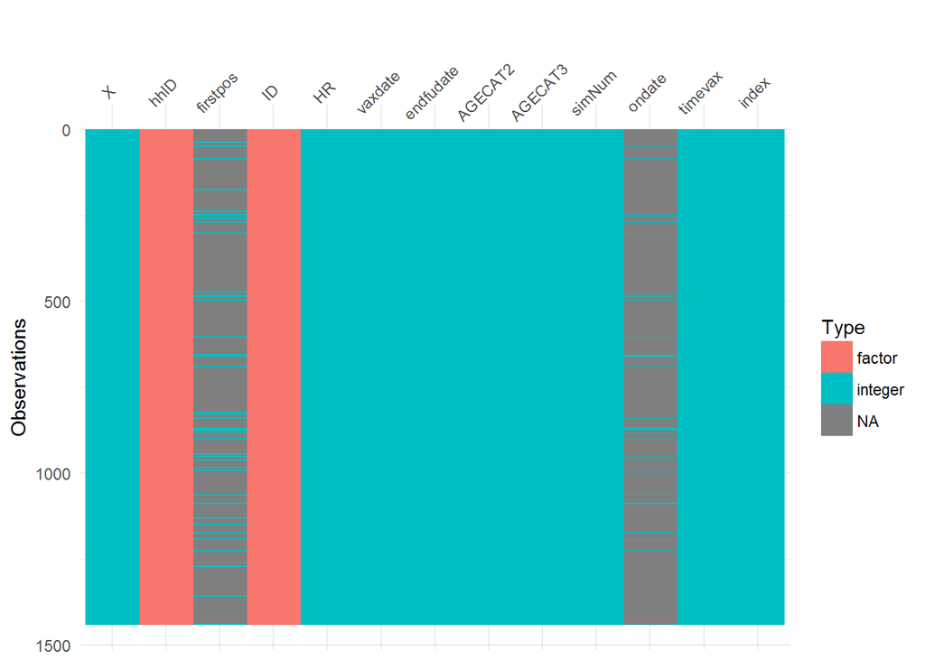

```r
setwd("S:/MartinEpi/Projects/BoV-Uganda/Graphs and Reports/HH-transmission-model-master_2/")
formdat1 <- read.csv("2017-01-25simData1.csv")

visdat::vis_dat(formdat1, sort_type = FALSE)
```

```r
glimpse(formdat1)
```

```
## Observations: 1,441
## Variables: 13
## $ X         <int> 1, 2, 3, 4, 5, 6, 7, 8, 9, 10, 11, 12, 13, 14, 15, 1...
## $ hhID      <fctr> 1049-1, 1049-1, 1049-1, 1049-1, 1050-1, 1050-1, 105...
## $ firstpos  <int> NA, NA, NA, NA, NA, NA, NA, NA, NA, NA, NA, NA, NA, ...
## $ ID        <fctr> 300211-1, 300210-1, 300209-1, 300208-1, 300215-1, 3...
## $ HR        <int> 0, 0, 0, 1, 1, 0, 0, 0, 0, 0, 0, 0, 1, 0, 0, 0, 0, 0...
## $ vaxdate   <int> 0, 0, 0, 0, 0, 0, 0, 999, 0, 0, 0, 0, 0, 0, 0, 999, ...
## $ endfudate <int> 104, 104, 104, 104, 104, 104, 104, 104, 104, 104, 10...
## $ AGECAT2   <int> 0, 0, 0, 0, 0, 0, 1, 0, 0, 1, 1, 0, 0, 0, 0, 0, 0, 0...
## $ AGECAT3   <int> 0, 0, 1, 1, 0, 0, 0, 1, 0, 0, 0, 1, 0, 0, 0, 1, 0, 0...
## $ simNum    <int> 1, 1, 1, 1, 1, 1, 1, 1, 1, 1, 1, 1, 1, 1, 1, 1, 1, 1...
## $ ondate    <int> NA, NA, NA, NA, NA, NA, NA, NA, NA, NA, NA, NA, NA, ...
## $ timevax   <int> 1, 1, 1, 1, 1, 1, 1, 0, 1, 1, 1, 1, 1, 1, 1, 0, 0, 0...
## $ index     <int> 0, 0, 0, 0, 0, 0, 0, 0, 0, 0, 0, 0, 0, 0, 0, 0, 0, 0...
```

```r
formdat1 <- formdat1 %>%
  select(-X, -simNum)
```

Why is endfudate (end of follow-up date) always 104 for all people?

```r
length(unique(formdat1$ID))   # 1441 individuals
```

```
## [1] 1441
```

```r
length(unique(formdat1$hhID)) # 328 households
```

```
## [1] 328
```

Read in proxy community hazard data: one row for each date of study follow up including counts of reported influenza cases standardized to the peak (i.e proxy in peak week == 1)

```r
setwd("S:/MartinEpi/Projects/BoV-Uganda/Graphs and Reports/HH-transmission-model-master_2/")
com <- read.csv("THmodel_exampleComData.csv")
```

remove superfluous data at end of ‘com’ data

```r
com <- com[1:105, ]
```

create a list of all hhIDs for later indexing

```r
hhIDs <- unique(formdat1$hhID)
length(hhIDs)
```

```
## [1] 328
```

328 households (same as above)

create a list of hhIDs where hh introduction of influenza occurred for later indexing

```r
ihhIDs <- unique(formdat1$hhID[which(!is.na(formdat1$firstpos))])
length(ihhIDs)
```

```
## [1] 39
```

39 infected households

```r
formdat1 %>%
  filter(!is.na(ondate)) %>%
  select(ID) %>%
  count()
```

```
## # A tibble: 1 x 1
##       n
##   <int>
## 1    58
```

58 flu cases in simulated data

```r
formdat1 %>%
  filter(!is.na(ondate)) %>%
  distinct(ID) %>%
  count()
```

```
## # A tibble: 1 x 1
##       n
##   <int>
## 1    58
```

Create a list of all the i (infected individuals) in each household: each list element contains 1 household, each row in each household element contains 1 infected individual

```r
infected <- vector("list", length(ihhIDs))

#  keep only i's w/ illness onset dates
pos <- formdat1[!is.na(formdat1$ondate), ]

for (i in 1:length(ihhIDs)) {
  # write each i's household ID, individual ID, own onset date,
  # their end of followup date
  infected[[i]] <- data.frame(
    hhID = ihhIDs[i],
    ID = pos$ID[pos$hhID %in% ihhIDs[i]],
    ondate = pos$ondate[pos$hhID %in% ihhIDs[i]],
    endfudate = pos$endfudate[pos$hhID %in% ihhIDs[i]]
    )
}

glimpse(pos)
```

```
## Observations: 58
## Variables: 11
## $ hhID      <fctr> 1057-1, 1060-1, 1068-1, 1068-1, 1068-1, 1090-1, 110...
## $ firstpos  <int> 81, 51, 89, 89, 89, 90, 68, 61, 81, 81, 78, 64, 64, ...
## $ ID        <fctr> 300245-1, 300256-1, 300293-1, 300294-1, 300290-1, 3...
## $ HR        <int> 0, 0, 0, 0, 1, 0, 0, 0, 0, 0, 0, 0, 0, 0, 0, 1, 0, 0...
## $ vaxdate   <int> 0, 0, 999, 999, 999, 0, 999, 0, 0, 0, 0, 999, 999, 0...
## $ endfudate <int> 104, 104, 104, 104, 104, 104, 104, 104, 104, 104, 10...
## $ AGECAT2   <int> 0, 0, 0, 0, 0, 0, 1, 0, 0, 0, 0, 0, 0, 0, 0, 0, 0, 0...
## $ AGECAT3   <int> 0, 1, 0, 0, 1, 1, 0, 0, 0, 0, 1, 0, 0, 0, 0, 0, 1, 1...
## $ ondate    <int> 81, 51, 91, 89, 94, 90, 68, 61, 81, 84, 78, 76, 64, ...
## $ timevax   <int> 1, 1, 0, 0, 0, 1, 0, 1, 1, 1, 1, 0, 0, 1, 1, 0, 0, 0...
## $ index     <int> 1, 1, 0, 1, 0, 1, 1, 1, 1, 0, 1, 0, 1, 1, 1, 1, 0, 1...
```

```r
# setwd("S:/MartinEpi/Projects/BoV-Uganda/Graphs and Reports/HH-transmission-model-master_2/premcmc_data")
# saveRDS(pos, "pos.rds")
# saveRDS(infected, "infected.rds")
```

Examine ‘infected’ list of tables.

```r
infected[[1]]
```

```
##     hhID       ID ondate endfudate
## 1 1057-1 300245-1     81       104
```

## Create preinfx.hh.exp

Here we format the data for the contribution to the hazard function of time at risk of household (d(i, j)) infection prior to infection or end of follow up

create an empty list to write in d(i, j) of hh exposure of j from each i infected prior to j

```r
preinf.hh.exp <- vector("list", nrow(formdat1))
```

loop through each individual, j

```r
for (j in 1:nrow(formdat1)) {
  # create empty vectors to keep track of current j's ID and hhID
  curhhID <- curID <- temp <- NA
  # empty vector for the last day of j's exposure
  end <- as.Date(NA)
  # write hhID and ID of the current j
  curhhID <- formdat1$hhID[j]
  curID <- formdat1$ID[j]
  # end is either the studyend date (if j wasn't infected) or
  # the day before ondate of j (if j was infected)
  end <- ifelse(is.na(formdat1$ondat[j]),
                 formdat1$endfudate[j],
                 formdat1$ondate[j] - 1)

  # write data for each hh exposure date, d(i, j), starting from onset date of i
  # through + 14 days after i's onset date or end, whichever comes first

  # if j has onset before first i or no hh introduction, set hh exposure to missing
  if (formdat1$firstpos[j] > end | is.na(formdat1$firstpos[j])) {
    preinf.hh.exp[[j]] <- NA
    next
  } else {
    # get info of all i in the same household
    temp <- infected[[which(ihhIDs %in% formdat1$hhID[j])]]
    # exclude i if their onset date was later than j's end
    temp <- temp[temp$ondate <= end, ]
    # do not include current j as i
    temp <- temp[!(temp$ID %in% curID), ]

    # if no eligible i, hh exposure <-NA
    if (nrow(temp) == 0) {
      preinf.hh.exp[[j]] <- NA
      next
      } else {
        # create an empty list, one element contains one i for j
        exp <- vector("list", nrow(temp))
        # Loop through each i
        for (i in 1:nrow(temp)) {
          # get season dates from i's onset to i's onset +14 days
          tempmin <- min(end, (temp$ondate[i] + 14))
          tempdays <- seq(temp$ondate[i], tempmin, by = 1)
          # one row per each season date
          temprows <- rep(row.names(temp[i, ]), length(tempdays))
          exp[[i]] <- temp[i, ][temprows, ]
          # write season dates
          exp[[i]]$date <- tempdays
          # write exposure dates, d(i,j), as season date minus i's onset date
          exp[[i]]$expday <- as.numeric(exp[[i]]$date - exp[[i]]$ondate)
          # write covariate (here, 9 >= AGE < 18 of j)
          exp[[i]]$AGECAT2 <- formdat1$AGECAT2[j]
          # write covariate (here, AGE =< 18 of j)
          exp[[i]]$AGECAT3 <- formdat1$AGECAT3[j]
          # write covariate (here, HIGH RISK STATUS of j)
          exp[[i]]$HR <- formdat1$HR[j]
          # write time varying covariate (here, VACCINATION STATUS of j)
          exp[[i]]$vaxdate <- formdat1$vaxdate[j]
          exp[[i]]$vax <- ifelse(exp[[i]]$date < exp[[i]]$vaxdate, 0, 1)
          } # end for i in temp
        # collaspe 1st to ith exp into the jth element in preinf.hh.exp
        preinf.hh.exp[[j]] <- do.call(rbind, exp)
      } # end if else
  } # end if else
} # end for loop over jth individual

preinf.hh.exp[[35]]
```

```
##        hhID       ID ondate endfudate date expday AGECAT2 AGECAT3 HR
## 1    1057-1 300245-1     81       104   81      0       0       0  0
## 1.1  1057-1 300245-1     81       104   82      1       0       0  0
## 1.2  1057-1 300245-1     81       104   83      2       0       0  0
## 1.3  1057-1 300245-1     81       104   84      3       0       0  0
## 1.4  1057-1 300245-1     81       104   85      4       0       0  0
## 1.5  1057-1 300245-1     81       104   86      5       0       0  0
## 1.6  1057-1 300245-1     81       104   87      6       0       0  0
## 1.7  1057-1 300245-1     81       104   88      7       0       0  0
## 1.8  1057-1 300245-1     81       104   89      8       0       0  0
## 1.9  1057-1 300245-1     81       104   90      9       0       0  0
## 1.10 1057-1 300245-1     81       104   91     10       0       0  0
## 1.11 1057-1 300245-1     81       104   92     11       0       0  0
## 1.12 1057-1 300245-1     81       104   93     12       0       0  0
## 1.13 1057-1 300245-1     81       104   94     13       0       0  0
## 1.14 1057-1 300245-1     81       104   95     14       0       0  0
##      vaxdate vax
## 1          0   1
## 1.1        0   1
## 1.2        0   1
## 1.3        0   1
## 1.4        0   1
## 1.5        0   1
## 1.6        0   1
## 1.7        0   1
## 1.8        0   1
## 1.9        0   1
## 1.10       0   1
## 1.11       0   1
## 1.12       0   1
## 1.13       0   1
## 1.14       0   1
```

```r
# setwd("S:/MartinEpi/Projects/BoV-Uganda/Graphs and Reports/HH-transmission-model-master_2/premcmc_data")
# saveRDS(preinf.hh.exp, "preinf.hh.exp.rds")
```

## Create preinf.c.exp

Here we format the data for the contribution to the hazard function of time at risk of community (d(j)) infection prior to infection or end of follow up

create an empty list to write in d(j) of community exposure of each j

```r
preinf.c.exp <- vector("list", nrow(formdat1))
```

loop through each j

```r
for (j in 1:nrow(formdat1)) {
  # create empty vectors to keep track of current j's ID and hhID
  curhhID <- curID <- temp <- NA
  # empty vector for the last day of j's exposure
  end <- as.Date(NA)
  # write hhID and ID of the current j
  curhhID <- formdat1$hhID[j]
  curID <- formdat1$ID[j]
  # end is either the studyend date (if j wasn't infected) or
  # the day before j's illness onset date (if j was infected)
  end <- ifelse(is.na(formdat1$ondat[j]),
                 formdat1$endfudate[j],
                 formdat1$ondate[j] - 1)

  # write data for each com exposure date, d(j), starting from the start of the
  # season through the end of the season or end of follow up,
  # whichever comes first. There is 1 element in the list per j,
  # and 1 row in each element per exposure day, d(j)
  # Data include d(j), and all covariates to be included in regression model,
  # here age, high risk status, and time-varying vaccination status.
  preinf.c.exp[[j]] <- data.frame(
    date = seq(0, end, by = 1),
    AGECAT2 = formdat1$AGECAT2[j],
    AGECAT3 = formdat1$AGECAT3[j],
    HR = formdat1$HR[j],
    vaxdate = formdat1$vaxdate[j]
    )

    for (i in 1:length(preinf.c.exp[[j]][, 1])) {
      preinf.c.exp[[j]]$com[i] <- com$COM[i]
      condition <- preinf.c.exp[[j]]$vaxdate[i] > preinf.c.exp[[j]]$date[i]
      preinf.c.exp[[j]]$vax[i] <- ifelse(condition, 0, 1)
    } # end for loop over jth individual
}

length(preinf.c.exp)
```

```
## [1] 1441
```

```r
head(preinf.c.exp[[1]]) # ID:300211-1/hhID:1049-1
```

```
##   date AGECAT2 AGECAT3 HR vaxdate        com vax
## 1    0       0       0  0       0 0.03761062   1
## 2    1       0       0  0       0 0.03761062   1
## 3    2       0       0  0       0 0.03761062   1
## 4    3       0       0  0       0 0.03761062   1
## 5    4       0       0  0       0 0.03761062   1
## 6    5       0       0  0       0 0.03761062   1
```

```r
# setwd("S:/MartinEpi/Projects/BoV-Uganda/Graphs and Reports/HH-transmission-model-master_2/premcmc_data")
# saveRDS(preinf.c.exp, "preinf.c.exp.rds")
```

## create ondate.hh.exp

Here we format the data for the contribution to the hazard function of time at risk of household d(i,j) infection on the day of illness onset of infected js

create empty list to write in d(i,j) of hh exposure of j from each i infected prior to j

```r
ondate.hh.exp <- vector("list", nrow(pos))
```

loop through each j

```r
for (j in 1:nrow(pos)) {
  # create empty vectors to keep track of current j's ID and hhID
  curhhID <- curID <- temp <- NA
  # empty vector for j's date of illness onset
  curondate <- as.Date(NA)
  # write hhID and ID of the current j
  curhhID <- pos$hhID[j]
  curID <- pos$ID[j]
  # write j's date of illness onset
  curondate <- pos$ondate[j]

  # write data for each hh exposure, d(i,j) on j's date of illness onset

  # if j is the first individual infected in the household, hh exposure <- NA
  if (pos$index[j] == 1) {
    ondate.hh.exp[[j]] <- NA
    next
    } else {
      # get info of all i in the same household
      temp <- infected[[which(ihhIDs %in% pos$hhID[j])]]
      # exclude i if their onset date was later than j's illness onset date
      temp <- temp[temp$ondate <= curondate, ]
      # do not include current j as i
      temp <- temp[!(temp$ID %in% curID), ]

      # create an empty list, one element contains one i for j
      exp <- vector("list", nrow(temp))

      # Loop through each i
      for (i in 1:nrow(temp)) {
        # one row of data for j's illness onset date
        exp[[i]] <- temp[i, ]
        # write season date of j's illness onset
        exp[[i]]$date <- curondate
        # write exposure date, d(i,j),
        # as j's illness onset date minus i's illness onset date
        exp[[i]]$expday <- as.numeric(exp[[i]]$date - exp[[i]]$ondate)
        # write covariate (here, 9 >= AGE < 18 of j)
        exp[[i]]$AGECAT2 <- pos$AGECAT2[j]
        # write covariate (here, AGE =< 18 of j)
        exp[[i]]$AGECAT3 <- pos$AGECAT3[j]
        # write covariate (here, HIGH RISK STATUS of j)
        exp[[i]]$HR <- pos$HR[j]
        # write time varying covariate (here, VACCINATION STATUS of j)
        exp[[i]]$vaxdate <- pos$vaxdate[j]
        condition <- exp[[i]]$date < exp[[i]]$vaxdate
        exp[[i]]$vax <- ifelse(condition, 0, 1)

        # collaspe 1st to ith exp into the jth element in ondate.hh.exp
        ondate.hh.exp[[j]] <- do.call(rbind, exp)
        } # end for over i
    } # end if-else
} # end for loop of jth individual

length(ondate.hh.exp)
```

```
## [1] 58
```

```r
ondate.hh.exp[[3]] # hhID: 1068-1, ID: 300294-1
```

```
##     hhID       ID ondate endfudate date expday AGECAT2 AGECAT3 HR vaxdate
## 2 1068-1 300294-1     89       104   91      2       0       0  0     999
##   vax
## 2   0
```

```r
# setwd("S:/MartinEpi/Projects/BoV-Uganda/Graphs and Reports/HH-transmission-model-master_2/premcmc_data")
# saveRDS(ondate.hh.exp, "ondate.hh.exp.eds")
```

first j in pos is hhID 1057-1 (ID: 300245-1) but they were the first (and only) infected in the household, so the algorithm moves to pos[2, ], where the situation is the same, moving to pos[3, ] we arrive at hhID 1068-1

## Create ondate.c.exp

Here we format the data for the contribution to the hazard function of time at risk of community d(j) infection on the date of illness onset of infected j’s

create an empty list to write in d(j) of community exposure of each j

```r
ondate.c.exp <- vector("list", nrow(pos))
```

loop through each j

```r
for ( j in 1:nrow(pos)) {
  # create empty vectors to keep track of current j's ID and hhID
  curhhID <- curID <- temp <- NA
  # empty vector for j's date of illness onset
  curondate <- as.Date(NA)
  # write hhID and ID of the current j
  curhhID <- pos$hhID[j]
  curID <- pos$ID[j]
  # write j's date of illness onset
  curondate <- pos$ondate[j]

  # Write data for com exposure, d(j), on the day of illness onset of j.
  # There is 1 element in the list per j, and 1 row in each element for
  # exposure on the date of illness onset, d(j).
  # Data include d(j), and all covariates to be included in regression model,
  # here age, high risk status, and time-varying vaccination status.
  ondate.c.exp[[j]] <- data.frame(
    date = curondate,
    AGECAT2 = pos$AGECAT2[j],
    AGECAT3 = pos$AGECAT3[j],
    HR = pos$HR[j],
    vaxdate = pos$vaxdate[j])
  for (i in 1:length(ondate.c.exp[[j]][, 1])) {
    com.index <- which(ondate.c.exp[[j]]$date[i] == com$DAY)
    ondate.c.exp[[j]]$com[i] <- com$COM[com.index]
    condition <- ondate.c.exp[[j]]$vaxdate[i] > ondate.c.exp[[j]]$date[i]
    ondate.c.exp[[j]]$vax[i] <- ifelse(condition, 0, 1)
  } # end for loop over ith hh member in jth individual
} # end for loop over jth individual

length(ondate.c.exp)
```

```
## [1] 58
```

```r
ondate.c.exp[[1]] # hhID: 1057-1, ID: 300245-1
```

```
##   date AGECAT2 AGECAT3 HR vaxdate       com vax
## 1   81       0       0  0       0 0.4535398   1
```

```r
ondate.c.exp[[2]]
```

```
##   date AGECAT2 AGECAT3 HR vaxdate com vax
## 1   51       0       1  0       0   1   1
```

```r
# setwd("S:/MartinEpi/Projects/BoV-Uganda/Graphs and Reports/HH-transmission-model-master_2/premcmc_data")
# saveRDS(ondate.c.exp, "ondate.c.exp")
```